# First small project in R, SDA 2022

Antoni Maciąg

2022-04-24

## 1, 2 - Data summary with plots

```
##       age            weight           height         gender
##  Min.   :17.00   Min.   : 45.20   Min.   :113.6   Length:500
##  1st Qu.:33.00   1st Qu.: 59.20   1st Qu.:155.6   Class :character
##  Median :39.00   Median : 67.50   Median :169.0   Mode  :character
##  Mean   :39.48   Mean   : 68.03   Mean   :168.2
##  3rd Qu.:45.00   3rd Qu.: 75.60   3rd Qu.:180.1
##  Max.   :72.00   Max.   :107.20   Max.   :235.2
##   married           children     building type         expenses
##  Mode :logical   Min.   :0.000   Length:500         Min.   : 524.9
##  FALSE:327       1st Qu.:0.750   Class :character   1st Qu.:1807.0
##  TRUE :173       Median :1.000   Mode  :character   Median :2489.9
##                  Mean   :1.558                      Mean   :2511.7
##                  3rd Qu.:2.000                      3rd Qu.:3084.5
##                  Max.   :6.000                      Max.   :5574.6
##     savings
##  Min.   :-685.68
##  1st Qu.:  74.52
##  Median : 402.22
##  Mean   : 478.60
##  3rd Qu.: 802.73
##  Max.   :3503.90
```

There are 500 observations. Qualitative variables are, as follows: marital status , gender, building type. The other variables are quantitative. Building types present in the date are: plattenbau, luxury apartment, single-family house, tenement, loft. Let us take a look at the Spearman correlation matrix of quantitative variables and visualize it with a heatmap:

```
##                   age      weight      height     children   expenses
## age       1.000000000 -0.07465814 -0.05105100  0.007687355  0.2331030
## weight   -0.074658138  1.00000000  0.68128552 -0.040112066 -0.1151614
## height   -0.051051001  0.68128552  1.00000000 -0.028732089 -0.1636114
## children  0.007687355 -0.04011207 -0.02873209  1.000000000  0.5964036
## expenses  0.233102970 -0.11516143 -0.16361141  0.596403595  1.0000000
```

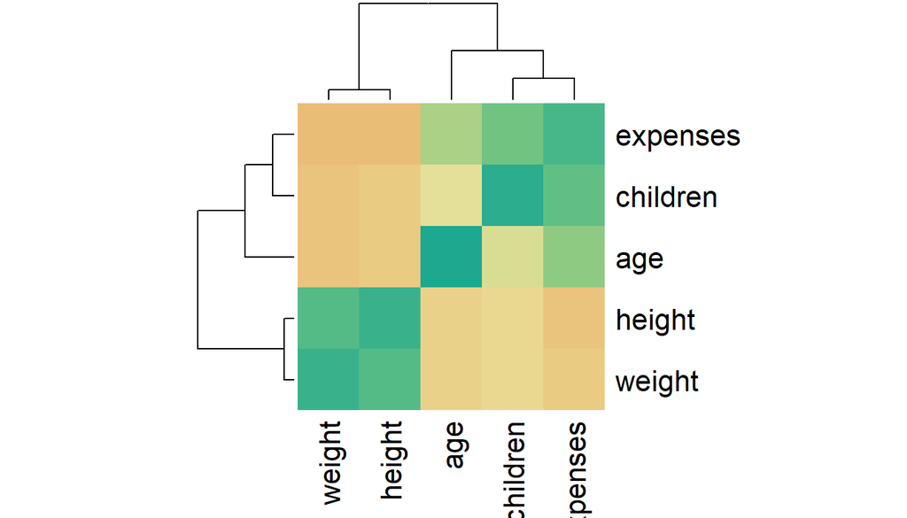

We can now visualize the most significant correlations with scatterplots.

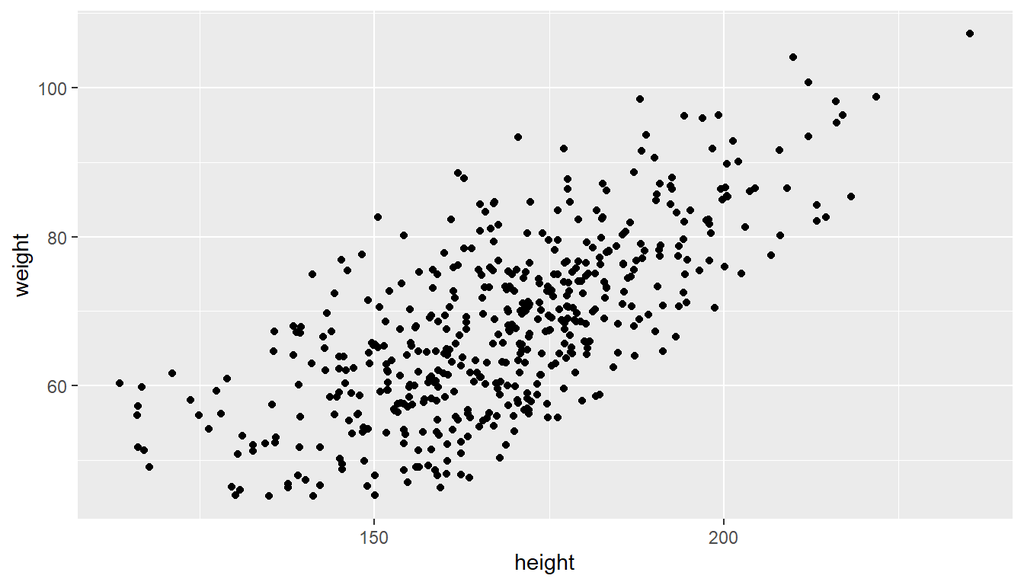

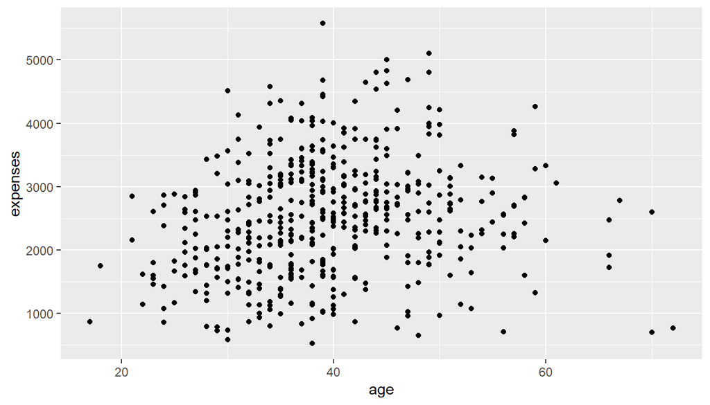

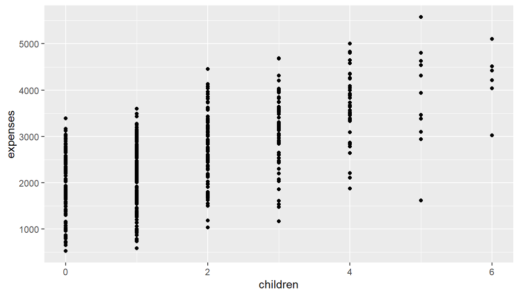

In addition, we can show all pair correlations in less detail:

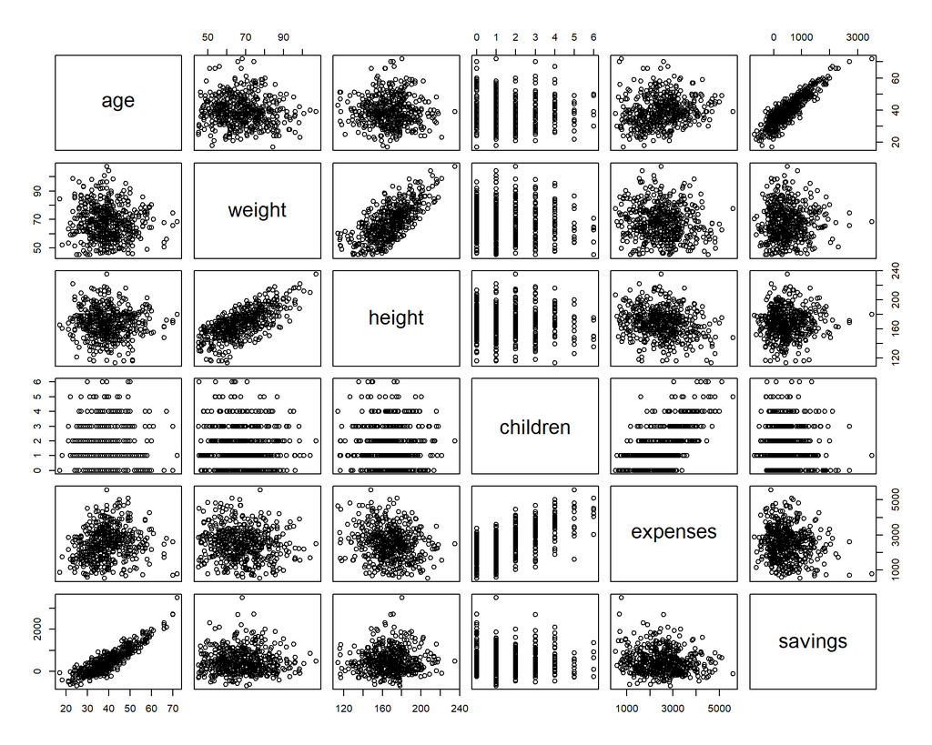

Now we can investigate the relationships between qualitative variables. For the relationship between marital status and gender, we can conduct a Fisher test:

```r
ftest <- fisher.test(people$gender, people$married)
```

The test results in a p-value of 0.1178612, giving us no reason to assume these variables are correlated.

At this point it might be fair to point out that some data is lacking - we do not know the gender of 38 people.

Now in order to investigate the relationship between marital status and type of inhabited building, we may create three pie charts, first the pie chart of building types for married people:

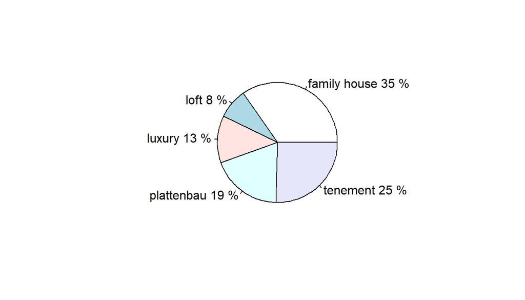

the same chart for unmarried people looks like this:

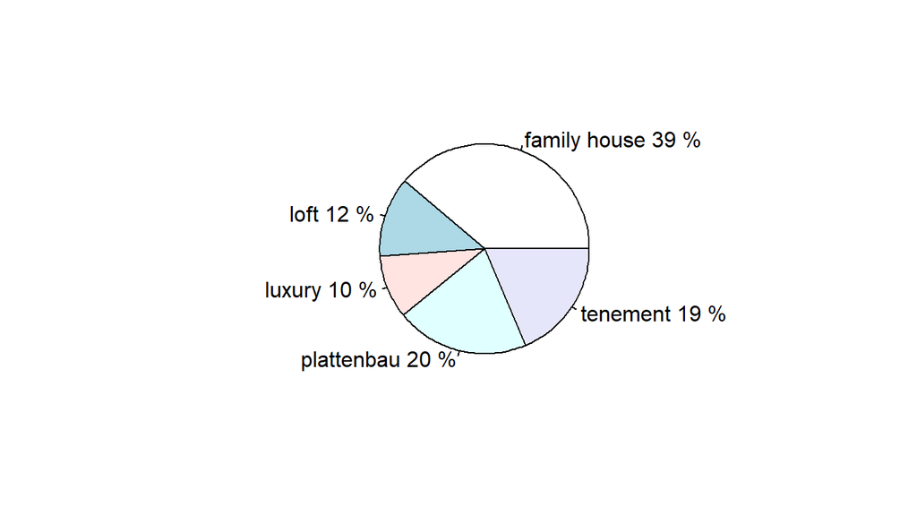

and the aggregate pie chart:

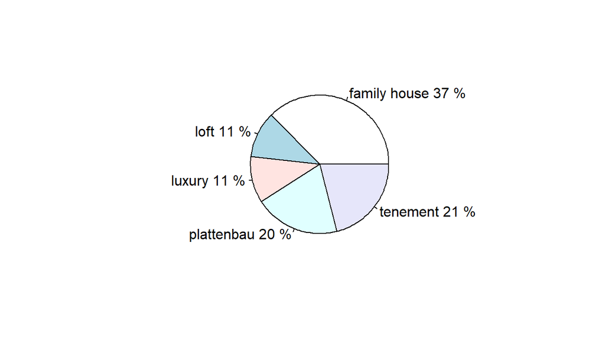

In the same way, we may investigate the relationship between gender and type of building. The chart for women:

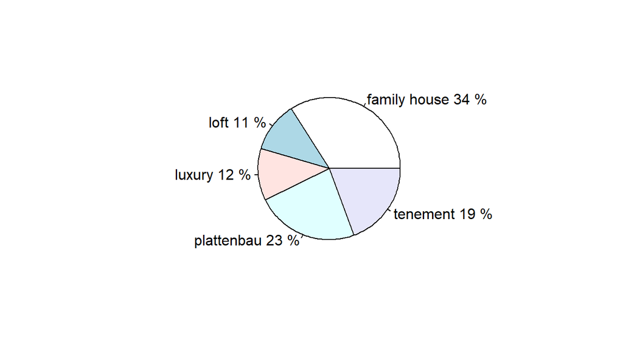

for men:

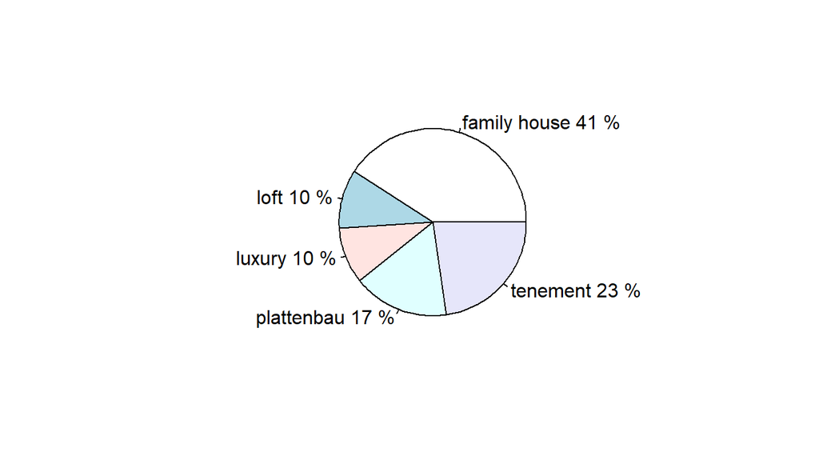

And the aggregate is the same.

Expenses in relationship to gender:

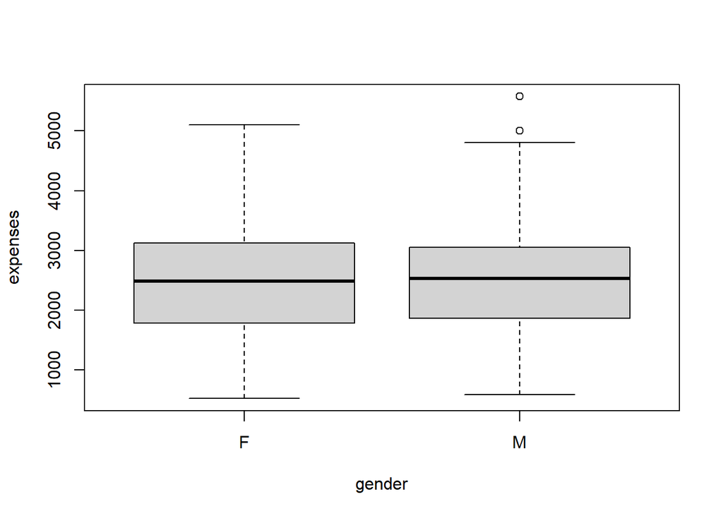

## 3 - testing hypotheses for mean and median

To test whether the mean height is equal to 170 cm, we would probably like to assume that the height distribution in the population is normal. We may test that with a q2q plot:

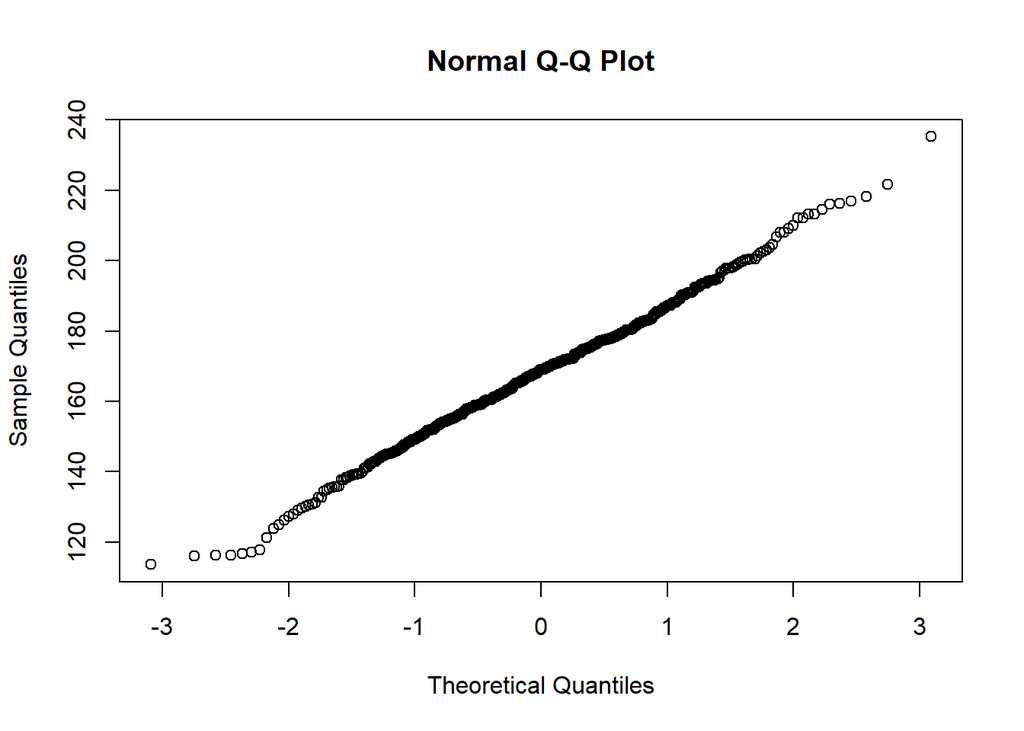

The plot looks mostly linear with some disturbance only in the tails. No observations seem to be outliers. Assuming normal distribution seems to be reasonable. We will now take advantage of the fact that, assuming $H_0$, the test statistic
$$M = \frac{\bar{X}-\mu_0}{S}\cdot\sqrt{n-1}$$
where $\bar{X}$ - mean of the sample, $\mu_0$ - hypothesized mean, $S^2$ - sample variance, $n$-sample size, follows Student’s t-distribution with $n-1$ degrees of freedom. Therefore, our $p$-value is equal to $T(M)$, where $T$ is the cumulative distribution function of this distribution.

```r
m0=170  # height in the data is also provided in centimeters
s2=var(people$height)
n=length(people$height)
X=mean(people$height)
M=(X-m0)/sqrt(s2) * sqrt(n-1)
pval = pt(M, n-1)
```

The obtained pvalue of 0.0195846 would give us fairly good grounds to reject $H_0$.

For the hypothesis about the median being equal to 165 vs. the alternative hypothesis - that it is less, we will conduct the Wilcoxon signed rank test. The test required that the distribution of the tested random variable be symmetrical. As mentioned above, we have good grounds to believe that it is normal, and thus indeed symmetrical.

```r
me0=165
wtest <- wilcox.test(people$height, alternative="less", mu=me0)
wtest$p.value
```

```
## [1] 0.9998678
```

This result gives us absolutely no grounds to reject $H_0$ in favor of $H_1$.

## 4 - confidence intervals for age

To analyze the mean, standard deviation and quantiles of age, we should first take a look at its distribution. It is noteworthy that it seems to be normal:

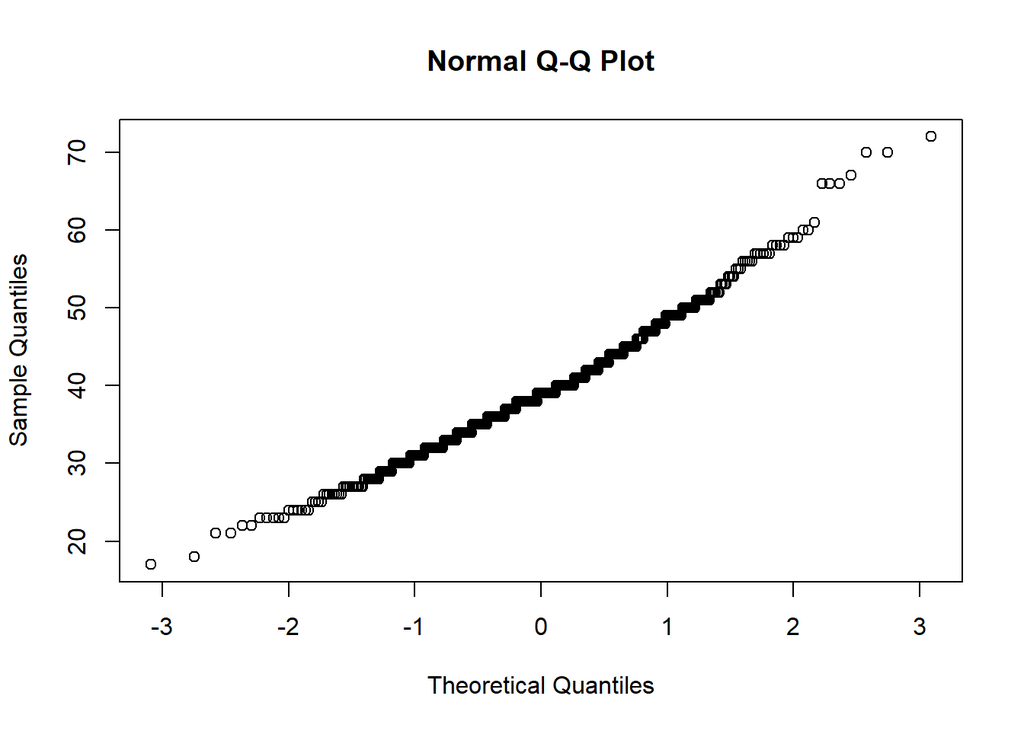

Not being detached from reality, we have to note that age has no reason to be distributed even remotely normally, which suggests that the data was generated randomly rather than sampled from any population. That said, mathematically it still kind of makes sense to analyze it as if it were normal. To estimate the mean, we may take advantage of the fact that the random variable
$$\frac{\bar{X}-\mu}{S_n}\cdot \sqrt{n-1}$$
where $S_n^2$ - sample variance, follows Student’s t-distribution (as long as $\bar{X}$ is normal). Hence, the confidence interval should look like:
$$t(0.005, n-1) \leq \frac{\bar{X}-\mu}{S_n}\cdot \sqrt{n-1} \leq t(0.995,
n-1)$$
where $t(x, k)$ is the quantile of degree $x$ of Student’s t-distribution with $k$ degrees of freedom.

```r
n = length(people$age)
Sn = sqrt(var(people$age))
lower_bound = -1* (qt(0.995, n-1) * Sn / sqrt(n-1) - mean(people$age))
upper_bound = -1* (qt(0.005, n-1) * Sn / sqrt(n-1) - mean(people$age))
```

Eventually giving us a confidence interval of (38.44, 40.52). To analyze the standard deviation of the sample, we will make use of the fact that the random variable

$$\frac{nS_n^2}{\sigma^2}$$
follows the $\chi^2$ distribution with $n-1$ degrees of freedom. Therefore
$$ch(0.005, n-1) \leq \frac{nS_n^2}{\sigma^2} \leq ch(0.995, n-1)$$

where $ch(x, k)$ is the quantile of degree $x$ of the chi-squared distribution with $k$ degrees of freedom.

```r
lower_bound = sqrt(n * Sn^2 / qchisq(0.995, n-1))
upper_bound = sqrt(n * Sn^2 / qchisq(0.05, n-1))
```

Now we may investigate the confidence intervals for quantiles of degree 0.25, 0.5, 0.75:

```
##      lower boundary upper boundary
## 0.25             32             35
## 0.5              38             40
## 0.75             43             47
```

## 5 - testing some more hypotheses

Now let us test the hypothesis that the average weight is the same for married and unmarriedpeople. The alternative hypothesis is that married people weigh less. Again, we check if the data is distributed normally:

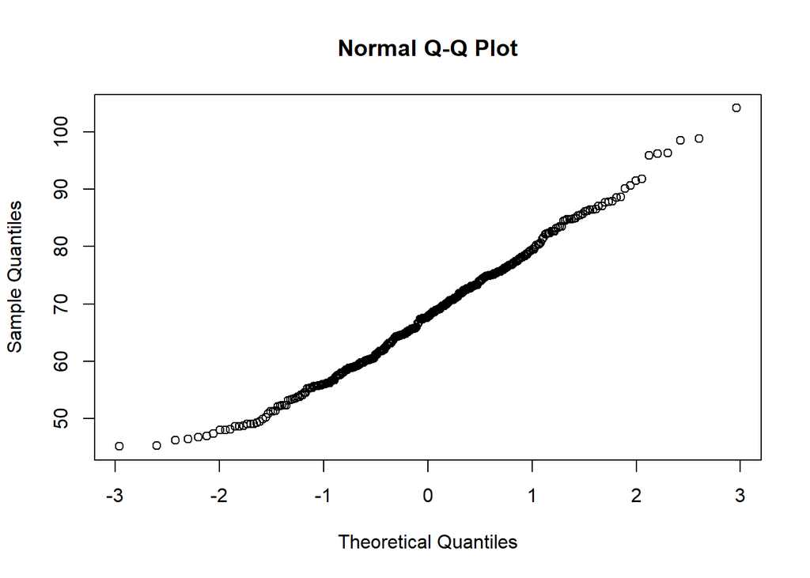

```r
qqnorm(unmarried_people$weight)
```

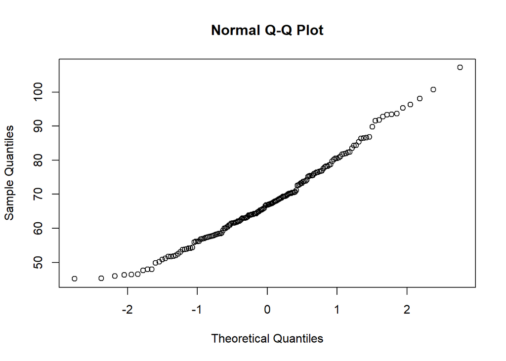

```r
qqnorm(married_people$weight)
```

We may note that the variances of the groups cannot be assumed to be equal. The variance of weights for unmarried people is equal to 130.73, and for married people it is 155.45. For this reason, we should use Welch’s t-test to test our hypothesis.

```r
welch <- t.test(married_people$weight, unmarried_people$weight, alternative="less")
```

With a p-value of 0.47, we may conclude that the null hypothesis should not be rejected.

```
##
##  Pearson's product-moment correlation
##
## data:  people$height and people$expenses
## t = -4.1666, df = 498, p-value = 3.645e-05
## alternative hypothesis: true correlation is not equal to 0
## 95 percent confidence interval:
##  -0.26693249 -0.09741533
## sample estimates:
##        cor
## -0.1835381
```

Apparently, the test shows that these variables are very likely slightly negatively correlated. The null hypothesis should be rejected.

Next, we will test whether marital status is independent from the type of inhabited building. Again, no special assumptions are required. The null hypothesis is that it is independent, the alternative is that it is not independent.

```r
chisq <- chisq.test(people$married, people$`building type`)
chisq
```

```
##
##  Pearson's Chi-squared test
##
## data:  people$married and people$`building type`
## X-squared = 5.807, df = 4, p-value = 0.214
```

The p-value of 0.21 does not justify rejecting the null hypothesis.

Now let us take a look at the histogram of people’s savings:

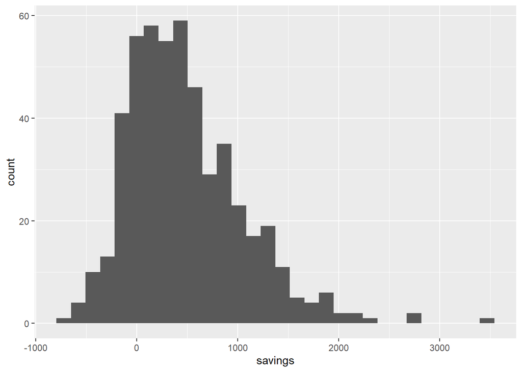

It kind of looks like a Gamma distribution with a few outliers (modulo having to move it right by 800 due to negative values). The parameters are not obvious, but by trial and error, I was able to come up with scale equal to $250$ and shape equal to $5$. Plotting a density function for the data (without the outliers) overlaid with the Gamma distribution looks like this:

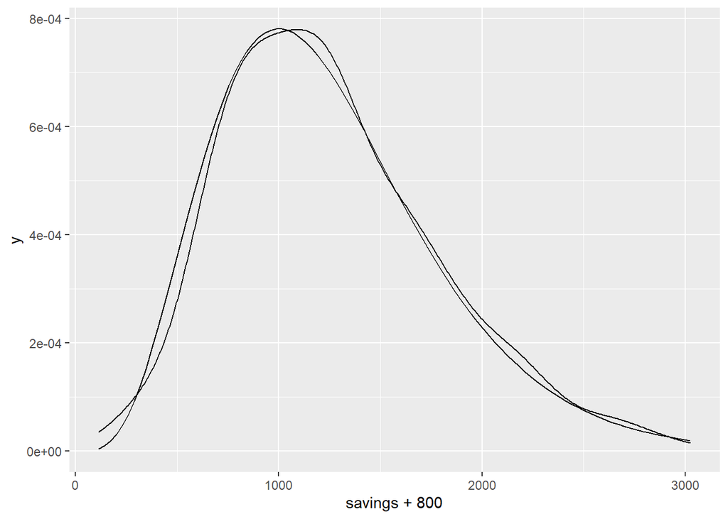

Goodness of fit will be tested with the Kolmogorov-Smirnov test. Our null hypothesis is that the sample comes from Gamma distribution with a scale of 250 and shape of 5. The alternative hypothesis is that this is not true. For the Kolmogorov-Smirnov test, it is good to first assess there are no duplicated values in our data:

```r
sum(duplicated(people_without_outliers$savings))
```

```
## [1] 0
```

Conveniently, this is the case, so we may conduct the test:

```
##
##  Asymptotic one-sample Kolmogorov-Smirnov test
##
## data:  people_without_outliers$savings + 800
## D = 0.036054, p-value = 0.5393
## alternative hypothesis: two-sided
```

We definitely have no grounds to reject $H_0$.

## 6 - linear model

At last, let us construct a linear regression model for savings as explained by the other variables.

```
##
## Call:
## lm(formula = savings ~ ., data = people)
##
## Residuals:
##     Min      1Q  Median      3Q     Max
## -307.64  -60.13   -1.69   58.06  462.98
##
## Coefficients:
##                             Estimate Std. Error t value Pr(>|t|)
## (Intercept)               -1.056e+03  5.780e+01 -18.266  < 2e-16 ***
## age                        6.394e+01  5.671e-01 112.750  < 2e-16 ***
## weight                     3.944e+00  5.694e-01   6.927 1.49e-11 ***
## height                    -2.385e+00  3.520e-01  -6.774 3.94e-11 ***
## genderM                    1.381e+00  9.632e+00   0.143    0.886
## marriedTRUE               -4.613e+00  1.291e+01  -0.357    0.721
## children                   1.516e+02  6.157e+00  24.623  < 2e-16 ***
## `building type`loft       -1.564e+02  2.219e+01  -7.047 6.91e-12 ***
## `building type`luxury      1.821e+02  1.644e+01  11.075  < 2e-16 ***
## `building type`plattenbau -3.822e+02  1.673e+01 -22.839  < 2e-16 ***
## `building type`tenement   -1.236e+02  1.319e+01  -9.368  < 2e-16 ***
## expenses                  -3.959e-01  1.057e-02 -37.455  < 2e-16 ***
## ---
## Signif. codes:  0 '***' 0.001 '**' 0.01 '*' 0.05 '.' 0.1 ' ' 1
##
## Residual standard error: 102 on 450 degrees of freedom
##   (38 observations deleted due to missingness)
## Multiple R-squared:  0.9673, Adjusted R-squared:  0.9665
## F-statistic:  1209 on 11 and 450 DF,  p-value: < 2.2e-16
```

Now let us diagnose the model.

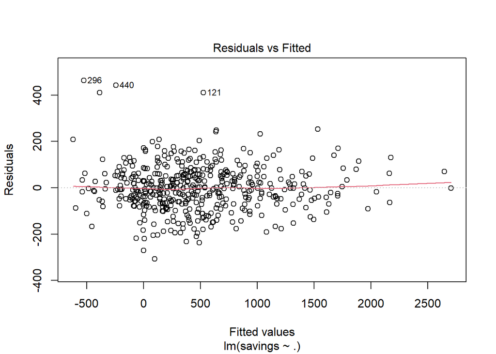

This plot shows that the relationship between the explanatory and explained variables is indeed linear, with independent residuals. The only thing that would suggest transforming the data is the presence outliers - observations 121, 296 and 440.

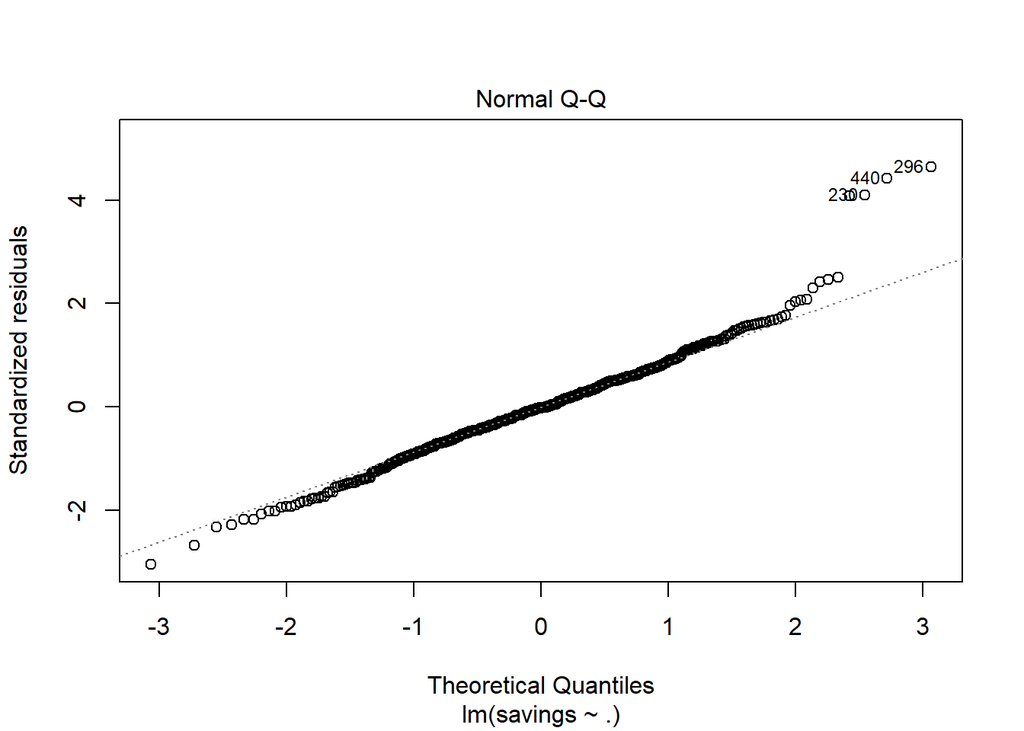

This plot shows that residues are distributed normally, which is very good. Again, the only exception is the outliers - this time 230, 296 and 440.

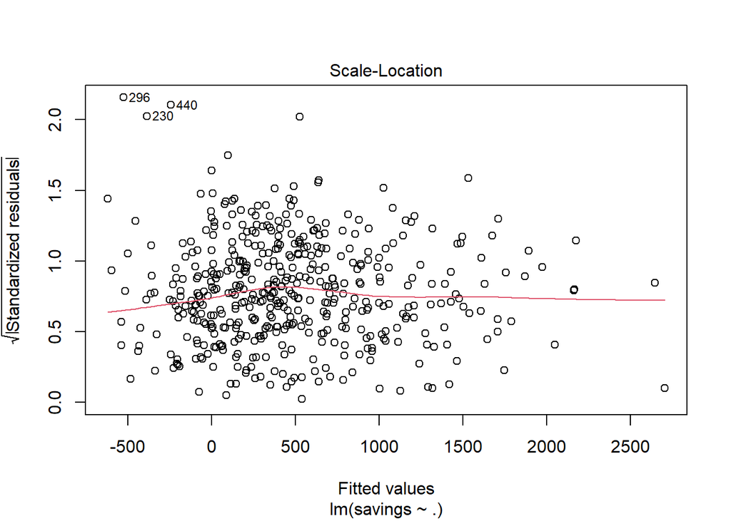

The fitted line (red) is quite horizontal, giving us good grounds to assume homoscedasticity of the residues. Outliers same as above.

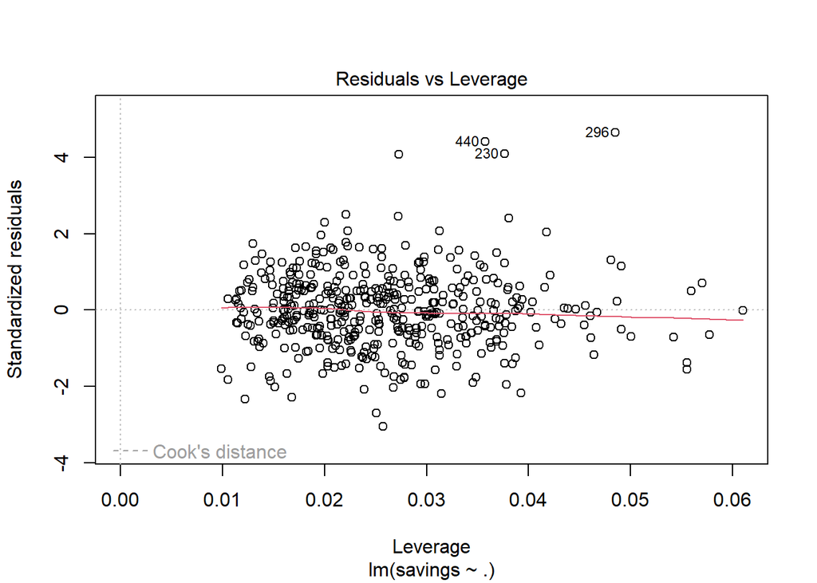

Again, the same three outliers can be seen, although here they are not explicitly marked so by a dotted red line. That said, based on the information from the other plots, we will remove observations 121, 230, 296 and 440 to improve the performance of the model. The parameters of the new model look like this:

```
##
## Call:
## lm(formula = savings ~ ., data = people_for_lm)
##
## Residuals:
##      Min       1Q   Median       3Q      Max
## -293.286  -55.027    0.438   57.535  297.441
##
## Coefficients:
##                             Estimate Std. Error t value Pr(>|t|)
## (Intercept)               -1.055e+03  5.257e+01 -20.060  < 2e-16 ***
## age                        6.486e+01  5.245e-01 123.663  < 2e-16 ***
## weight                     3.773e+00  5.197e-01   7.260 1.73e-12 ***
## height                    -2.428e+00  3.209e-01  -7.567 2.21e-13 ***
## genderM                    7.134e-02  8.789e+00   0.008    0.994
## marriedTRUE               -2.816e+00  1.174e+01  -0.240    0.811
## children                   1.573e+02  5.632e+00  27.939  < 2e-16 ***
## `building type`loft       -2.104e+02  2.089e+01 -10.073  < 2e-16 ***
## `building type`luxury      1.828e+02  1.494e+01  12.240  < 2e-16 ***
## `building type`plattenbau -3.916e+02  1.524e+01 -25.697  < 2e-16 ***
## `building type`tenement   -1.265e+02  1.199e+01 -10.551  < 2e-16 ***
## expenses                  -4.053e-01  9.658e-03 -41.962  < 2e-16 ***
## ---
## Signif. codes:  0 '***' 0.001 '**' 0.01 '*' 0.05 '.' 0.1 ' ' 1
##
## Residual standard error: 92.66 on 446 degrees of freedom
##   (38 observations deleted due to missingness)
## Multiple R-squared:  0.9731, Adjusted R-squared:  0.9724
## F-statistic:  1465 on 11 and 446 DF,  p-value: < 2.2e-16
```

Now we may compare how important different explanatory variables are for the prediction, in order to remove the least useful ones:

```
##                pvalues       r2_diff     rss_diff
## age       0.000000e+00 -9.233399e-01 1.313102e+08
## weight    1.733091e-12 -3.182532e-03 4.525949e+05
## height    2.213868e-13 -3.456846e-03 4.916058e+05
## gender    9.935272e-01 -3.978142e-09 5.657405e-01
## married   8.105213e-01 -3.474796e-06 4.941584e+02
## children 4.950242e-100 -4.713237e-02 6.702799e+06
## expenses 5.853554e-157 -1.063162e-01 1.511947e+07
```

```
##
## Call:
## lm(formula = savings ~ . - gender, data = people_for_lm)
##
## Residuals:
##      Min       1Q   Median       3Q      Max
## -293.244  -55.010    0.445   57.519  297.483
##
## Coefficients:
##                             Estimate Std. Error t value Pr(>|t|)
## (Intercept)               -1.055e+03  5.237e+01 -20.137  < 2e-16 ***
## age                        6.486e+01  5.239e-01 123.808  < 2e-16 ***
## weight                     3.773e+00  5.183e-01   7.279 1.52e-12 ***
## height                    -2.428e+00  3.205e-01  -7.575 2.08e-13 ***
## marriedTRUE               -2.827e+00  1.164e+01  -0.243    0.808
## children                   1.574e+02  5.595e+00  28.123  < 2e-16 ***
## `building type`loft       -2.104e+02  2.084e+01 -10.097  < 2e-16 ***
## `building type`luxury      1.828e+02  1.491e+01  12.260  < 2e-16 ***
## `building type`plattenbau -3.916e+02  1.521e+01 -25.739  < 2e-16 ***
## `building type`tenement   -1.265e+02  1.197e+01 -10.567  < 2e-16 ***
## expenses                  -4.053e-01  9.636e-03 -42.061  < 2e-16 ***
## ---
## Signif. codes:  0 '***' 0.001 '**' 0.01 '*' 0.05 '.' 0.1 ' ' 1
##
## Residual standard error: 92.56 on 447 degrees of freedom
##   (38 observations deleted due to missingness)
## Multiple R-squared:  0.9731, Adjusted R-squared:  0.9725
## F-statistic:  1615 on 10 and 447 DF,  p-value: < 2.2e-16
```

And the renewed diagnostic plots:

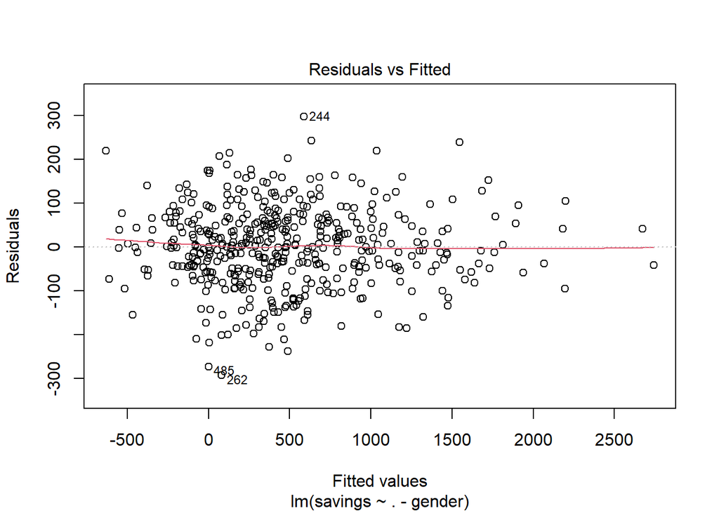

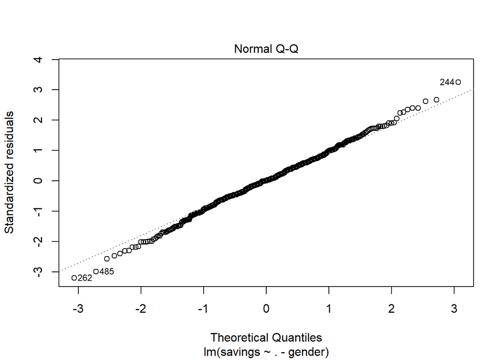

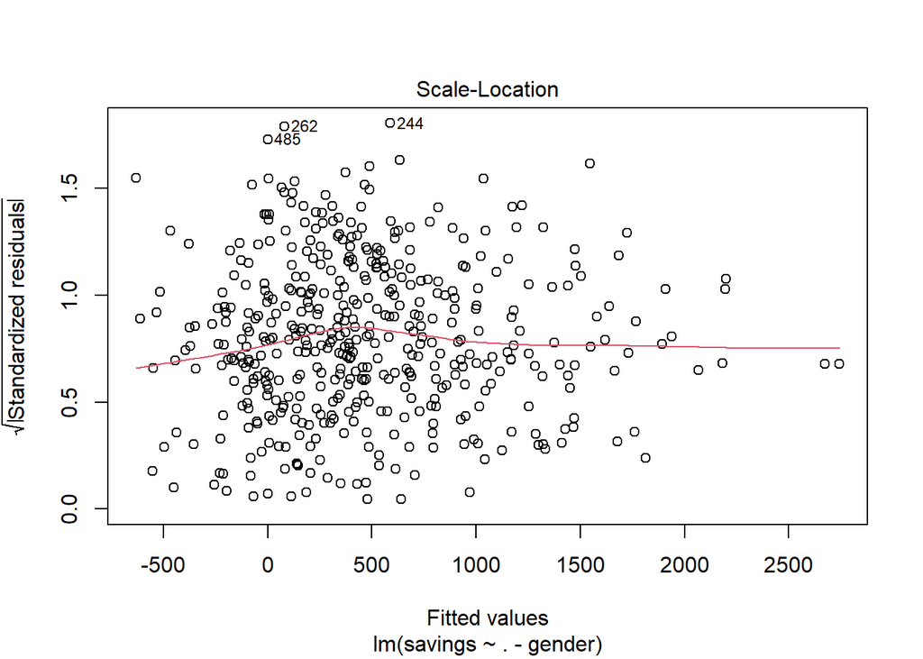

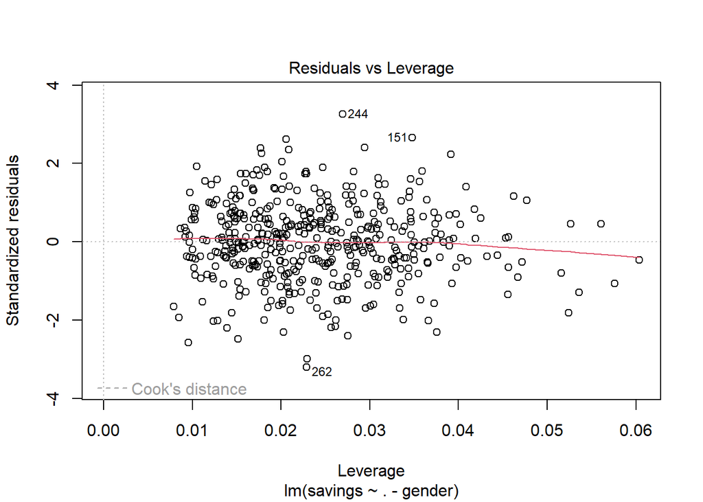

The conclusions that can be drawn from these plots are similar as above.